# 利用R分析餐饮企业数据初步

## 贡献度分析

### 概述

贡献度分析又称帕累托分析，它的原理是帕累托法则又称20/80定律。同样的投入放在不同的地方会产生不同的效益。例如对于一个公司来讲，80%的利润常常来自于20%最畅销的产品，然而其他80%的产品只产生了20%的利润。

就餐饮行业来说，应用贡献度分析可以重点改善菜系盈利占总额80%的菜品。这种结果可以从帕累托图中直观地看出。

### 读取数据

```r
library(knitr)
dishdata <- read.csv(file = "./catering_dish_profit.csv")
kable(dishdata[1:5,])
```

| 菜品ID | 菜品名 | 盈利 |
| --- | --- | --- |
| 17148 | A1 | 9173 |
| 17154 | A2 | 5729 |
| 109 | A3 | 4811 |
| 117 | A4 | 3594 |
| 17151 | A5 | 3195 |

### 作帕累托图

有了数据，我们就可以利用已经写好的代码来作出贡献度图表了，只需将数据代入其中即可:

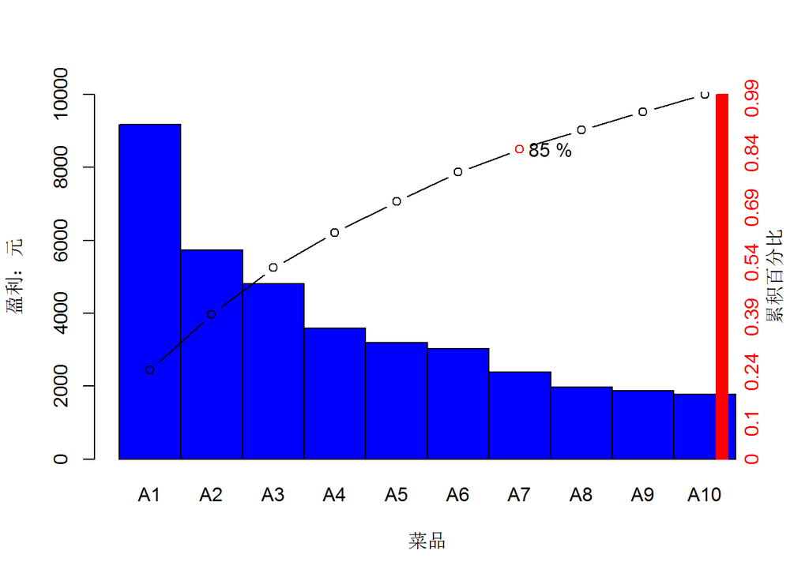

通过图表我们可以很直观得看到，菜品A1到A7一共创造了85%的盈利，这就是我们需要重点发展和维护的菜品。

## 菜品的相关性分析

### 概述

```r
cordata <- read.csv(file = "./catering_sale_all.csv", header = TRUE)

kable(cordata[1:5,])
```

| 日期 | 百合酱蒸凤爪 | 翡翠蒸香茜饺 | 金银蒜汁蒸排骨 | 乐膳真味鸡 | 蜜汁焗餐包 | 生炒菜心 | 铁板酸菜豆腐 | 香煎韭菜饺 | 香煎罗卜糕 | 原汁原味菜心 |
| --- | --- | --- | --- | --- | --- | --- | --- | --- | --- | --- |
| 2015/1/1 | 17 | 6 | 8 | 24 | 13 | 13 | 18 | 10 | 10 | 27 |
| 2015/1/2 | 11 | 15 | 14 | 13 | 9 | 10 | 19 | 13 | 14 | 13 |
| 2015/1/3 | 10 | 8 | 12 | 13 | 8 | 3 | 7 | 11 | 10 | 9 |
| 2015/1/4 | 9 | 6 | 6 | 3 | 10 | 9 | 9 | 13 | 14 | 13 |
| 2015/1/5 | 4 | 10 | 13 | 8 | 12 | 10 | 17 | 11 | 13 | 14 |

我们又通过代码获取了一组模拟数据，通过表格可知。这也是餐饮行业中最常见的统计表格之一，它记录了每一天菜单上各种菜品的销量。表格看起来枯燥无味，数据中似乎也看不出什么来，只是每天记录的日常数据而已。可是通过关联分析函数，我们能够发现蕴藏在数据背后的相关性模式。比如我们就关注百合酱蒸凤爪这道菜，看看它和其他菜品有着哪些关联。

```r
corr = cor(cordata[, 2],cordata[,3:11])
kable(corr)
```

| 翡翠蒸香茜饺 | 金银蒜汁蒸排骨 | 乐膳真味鸡 | 蜜汁焗餐包 | 生炒菜心 | 铁板酸菜豆腐 | 香煎韭菜饺 | 香煎罗卜糕 | 原汁原味菜心 |
| --- | --- | --- | --- | --- | --- | --- | --- | --- |
| 0.0092058 | 0.0167993 | 0.4556382 | NA | 0.3084956 | 0.2048978 | 0.1274482 | -0.0902755 | 0.4283163 |

由于缺失值的出现，相关系数计算结果中也出现了NA，这是统计学中很常见的情况，但是这没有影响到我们观测其他菜品数据。从上面的结果可以看到如果顾客点了“百合酱蒸凤爪”，则点“翡翠蒸香茜饺”、“金银蒜汁蒸排骨”、“香煎萝卜糕”、“铁板酸菜豆腐”、“香煎韭菜饺”等主食的相关性比较低，反而点“乐膳真味鸡”、“生炒菜心”、“原汁原味菜心”的相关性比较高。

我们用相关性分析法对“百合酱蒸凤爪”进行了简单的建模分析之后，看到了不同菜品与之的相关性，相关性比较高，意味着顾客点了凤爪之后还会点这些菜的几率很大，普遍顾客喜欢将这它们一起点。所以我们可以利用这些信息来构建推荐系统，当顾客点了凤爪，我们可以为他们推荐相关性高的菜品。